# Do intros work?

# 1. Load packages

```r
library(tidyverse)
library(here)
library(knitr)
library(jsonlite)
library(readr)
library(lme4)
library(lmerTest)
library(emmeans)
library(mediation)
library(semTools)
library(ggplot2)
library(lavaan)
library(dplyr)
library(tidyr)
library(semPlot)
library(DiagrammeR)
library(performance)
library(sjPlot)
library(interactions)
library(patchwork)
library(glmmTMB)
library(gt)
library(scales)
library(fastDummies)
library(glue)
library(brms)
library(cmdstanr)
library(ordbetareg)
library(posterior)
library(modelsummary)
library(bayesplot)
library(ggeffects)
library(webshot2)
```

# 2. Load dataset

```r
# 1. Load the main filtered dataset
data_path <- here::here("data", "long_df_scored.csv")
data <- readr::read_csv(data_path)
```

Let’s check everything is good:

```r
View(data)
```

# 3. TBS & TDS by introduction style

Let’s start with a table: **TBS**

```r
# Filter for the relevant population: High Unusualness
tbs_summary <- data |>
  filter(se_1 > 3) |>
  group_by(intro) |>
  summarise(
    n_at_risk = n(),
    n_tbs     = sum(tbs, na.rm = TRUE),
    pct_tbs   = mean(tbs, na.rm = TRUE)
  ) |>
  ungroup()

# Create the TBS specific table
tbs_table <- tbs_summary |>
  gt() |>
  fmt_percent(columns = pct_tbs, decimals = 1) |>
  cols_label(
    intro = "Introduction Type",
    n_at_risk = "N (Unusual Songs)",
    n_tbs = "TBS Count",
    pct_tbs = "TBS Rate (%)"
  ) |>
  tab_header(
    title = "Prevalence of Taste Broadening Serendipity (TBS)",
    subtitle = "Condition: se_1 > 3 (Outside Typical Preferences)"
  ) |>
  opt_table_lines(extent = "default")

tbs_table
```

Prevalence of Taste Broadening Serendipity (TBS)

Condition: se_1 > 3 (Outside Typical Preferences)

| Introduction Type | N (Unusual Songs) | TBS Count | TBS Rate (%) |
| --- | --- | --- | --- |
| immersive_introduction | 271 | 121 | 44.6% |
| informative_introduction | 279 | 148 | 53.0% |
| no_introduction | 271 | 97 | 35.8% |

**TDS**

```r
# Filter for the relevant population: Low Unusualness
tds_summary <- data |>
  filter(se_1 < 4) |>
  group_by(intro) |>
  summarise(
    n_at_risk = n(),
    n_tds     = sum(tds, na.rm = TRUE),
    pct_tds   = mean(tds, na.rm = TRUE)
  ) |>
  ungroup()

# Create the TDS specific table
tds_table <- tds_summary |>
  gt() |>
  fmt_percent(columns = pct_tds, decimals = 1) |>
  cols_label(
    intro = "Introduction Type",
    n_at_risk = "N (Usual Items)",
    n_tds = "TDS Count",
    pct_tds = "TDS Rate (%)"
  ) |>
  tab_header(
    title = "Prevalence of Taste Deepening Serendipity (TDS)",
    subtitle = "Condition: se_1 < 4 (Within Typical Preferences)"
  ) |>
  opt_table_lines(extent = "default")

tds_table
```

Prevalence of Taste Deepening Serendipity (TDS)

Condition: se_1 < 4 (Within Typical Preferences)

| Introduction Type | N (Usual Items) | TDS Count | TDS Rate (%) |
| --- | --- | --- | --- |
| immersive_introduction | 181 | 65 | 35.9% |
| informative_introduction | 173 | 91 | 52.6% |
| no_introduction | 181 | 33 | 18.2% |

Introductions seem to be very effective in stimulating taste-deepening serendipity.

Let’s also take a look at only interest:

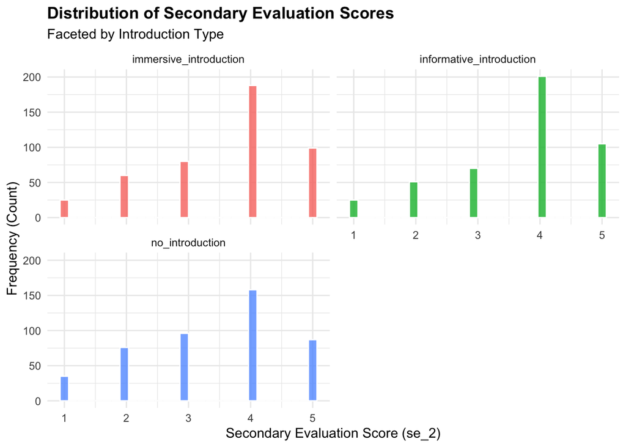

```r
# Generate a faceted histogram of se_2 separated by introduction type
se_2_plot <- data |>
  ggplot(aes(x = se_2, fill = intro)) +
  geom_histogram(
    bins = 30,         # Adjust bins based on the specific range of se_2
    alpha = 0.8,
    color = "white"    # Adds clean borders to the histogram bars
  ) +
  facet_wrap(~ intro, ncol = 2) +
  labs(
    title = "Distribution of Secondary Evaluation Scores",
    subtitle = "Faceted by Introduction Type",
    x = "Secondary Evaluation Score (se_2)",
    y = "Frequency (Count)"
  ) +
  theme_minimal() +
  theme(
    legend.position = "none",
    plot.title = element_text(face = "bold")
  )

# Display the plot
se_2_plot
```

## 3.1. Regression

We do a multilevel logistic regression to check the significance of introduction in stimulating taste-broadening serendipity.

First, we split the data based on the part relevant for the tbs and the tds analysis:

```r
# Prepare data for TBS Model (Condition: High Unusualness)
tbs_data <- data |>
  filter(se_1 > 3) |>
  mutate(intro = relevel(as.factor(intro), ref = "no_introduction"))

# Prepare data for TDS Model (Condition: Low Unusualness)
tds_data <- data |>
  filter(se_1 < 4) |>
  mutate(intro = relevel(as.factor(intro), ref = "no_introduction"))

# Verify the sample sizes for the models
nrow(tbs_data)
```

```
[1] 821
```

```r
nrow(tds_data)
```

```
[1] 535
```

Now we will fit the models. Our data is nested in both session ids and song names seperately.

```r
library(brms)
library(cmdstanr)

# --- Model 1: Taste Broadening Serendipity (TBS) ---
m_tbs <- brm(
  formula = tbs ~ intro + se_8 + (1 | sess_id) + (1 | name),
  data = tbs_data,
  family = bernoulli(link = "logit"),
  backend = "cmdstanr",
  chains = 4,
  cores = 4,
  iter = 2000,
  seed = 42
  #file = "models/m_tbs_binary" # Saves model to avoid refitting
)

# --- Model 2: Target Deviance Serendipity (TDS) ---
m_tds <- brm(
  formula = tds ~ intro + se_8 + (1 | sess_id) + (1 | name),
  data = tds_data,
  family = bernoulli(link = "logit"),
  backend = "cmdstanr",
  chains = 4,
  cores = 4,
  iter = 2000,
  seed = 42
  #file = "models/m_tds_binary" # Saves model to avoid refitting
)
```

Let’s turn this into a nice table:

```r
# Helper function to extract and format ORs
get_odds_ratios <- function(model, model_name) {
  fixef(model) |>
    as.data.frame() |>
    rownames_to_column("Term") |>
    mutate(
      OR = exp(Estimate),
      Lower_CI = exp(Q2.5),
      Upper_CI = exp(Q97.5),
      Model = model_name
    ) |>
    dplyr::select(Model, Term, OR, Lower_CI, Upper_CI)
}

# Combine results
tbs_res <- get_odds_ratios(m_tbs, "TBS (Unusual Items)")
tds_res <- get_odds_ratios(m_tds, "TDS (Usual Items)")

# Display combined table
bind_rows(tbs_res, tds_res) |>
  filter(Term != "Intercept") |> # Hide intercept for clarity
  knitr::kable(digits = 2, caption = "Bayesian Odds Ratios for TBS and TDS")
```

[output not shown]

# 4. TBS & TDS by song and introduction style

Let’s zoom in on these effects by looking per song. We start with TBS:

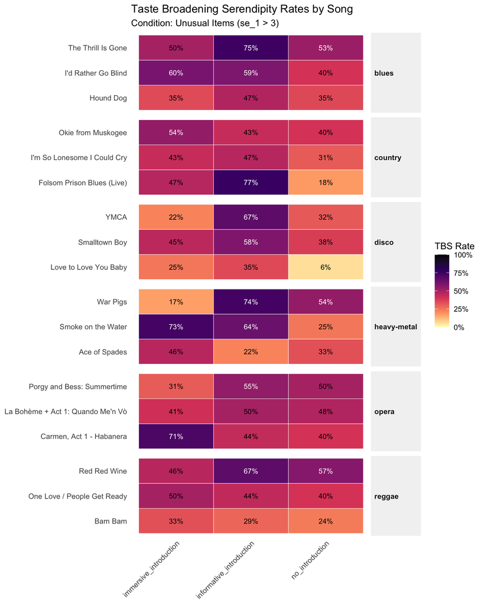

```r
# 1. Prepare Data for TBS (High Unusualness)
tbs_plot_data <- data |>
  filter(se_1 > 3) |>
  group_by(genre, name, intro) |>
  summarise(
    n = n(),
    success_count = sum(tbs, na.rm = TRUE),
    prop = mean(tbs, na.rm = TRUE),
    .groups = "drop"
  )

# 2. Generate TBS Heatmap
ggplot(tbs_plot_data, aes(x = intro, y = name, fill = prop)) +
  geom_tile(color = "white") +

  # Dynamic Text Color: White on dark tiles, Black on light tiles
  geom_text(
    aes(
      label = scales::percent(prop, accuracy = 1),
      color = ifelse(prop > 0.5, "white", "black")
    ),
    size = 3
  ) +

  scale_color_identity() +

  # Facet by Genre
  facet_grid(genre ~ ., scales = "free_y", space = "free_y") +

  # Color Scale: Magma (Darker = Higher %)
  scale_fill_viridis_c(
    name = "TBS Rate",
    labels = scales::percent,
    option = "magma",
    direction = -1,
    limits = c(0, 1) # Fix scale 0-100%
  ) +

  labs(
    title = "Taste Broadening Serendipity Rates by Song",
    subtitle = "Condition: Unusual Items (se_1 > 3)",
    x = NULL,
    y = NULL
  ) +
  theme_minimal() +
  theme(
    panel.grid = element_blank(),
    axis.text.x = element_text(angle = 45, hjust = 1),
    strip.text.y = element_text(angle = 0, face = "bold", hjust = 0),
    strip.background = element_rect(fill = "grey95", color = NA)
  )
```

And now TDS:

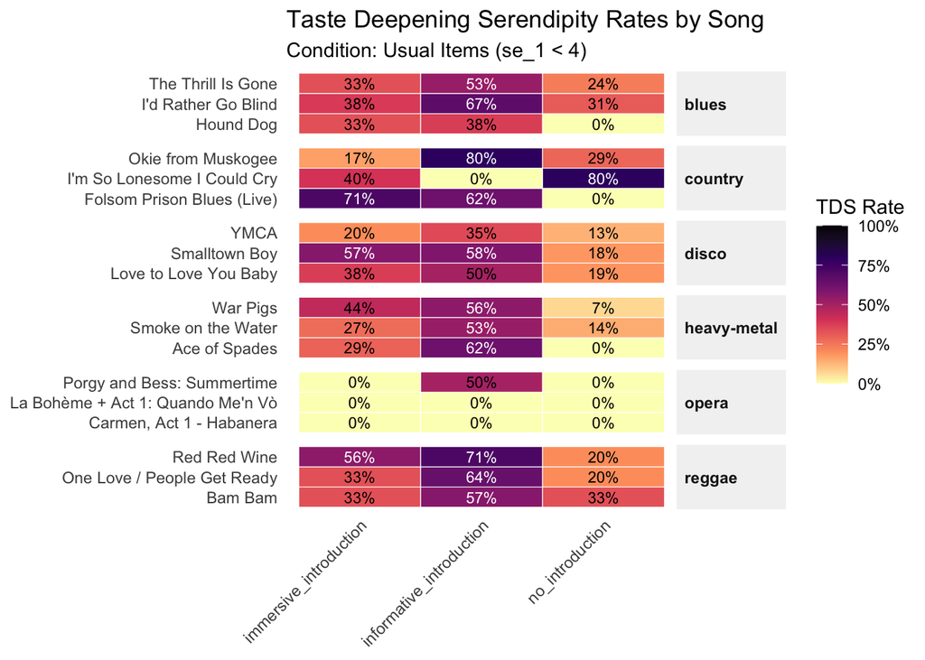

```r
##| label: plot-tds-heatmap
#| echo: true
#| eval: true
#| fig.height: 10
#| fig.width: 8
#| message: false

# 1. Prepare Data for TDS (Low Unusualness)
tds_plot_data <- data |>
  filter(se_1 < 4) |>
  group_by(genre, name, intro) |>
  summarise(
    n = n(),
    success_count = sum(tds, na.rm = TRUE),
    prop = mean(tds, na.rm = TRUE),
    .groups = "drop"
  )

# 2. Generate TDS Heatmap
ggplot(tds_plot_data, aes(x = intro, y = name, fill = prop)) +
  geom_tile(color = "white") +

  # Dynamic Text Color
  geom_text(
    aes(
      label = scales::percent(prop, accuracy = 1),
      color = ifelse(prop > 0.5, "white", "black")
    ),
    size = 3
  ) +

  scale_color_identity() +

  # Facet by Genre
  facet_grid(genre ~ ., scales = "free_y", space = "free_y") +

  # Color Scale: Same as TBS for consistency
  scale_fill_viridis_c(
    name = "TDS Rate",
    labels = scales::percent,
    option = "magma",
    direction = -1,
    limits = c(0, 1)
  ) +

  labs(
    title = "Taste Deepening Serendipity Rates by Song",
    subtitle = "Condition: Usual Items (se_1 < 4)",
    x = NULL,
    y = NULL
  ) +
  theme_minimal() +
  theme(
    panel.grid = element_blank(),
    axis.text.x = element_text(angle = 45, hjust = 1),
    strip.text.y = element_text(angle = 0, face = "bold", hjust = 0),
    strip.background = element_rect(fill = "grey95", color = NA)
  )
```

Let’s construct a similar map but illustrating perceived quality of the introduction per song:

Heatmap **Outside Typical Preferences**

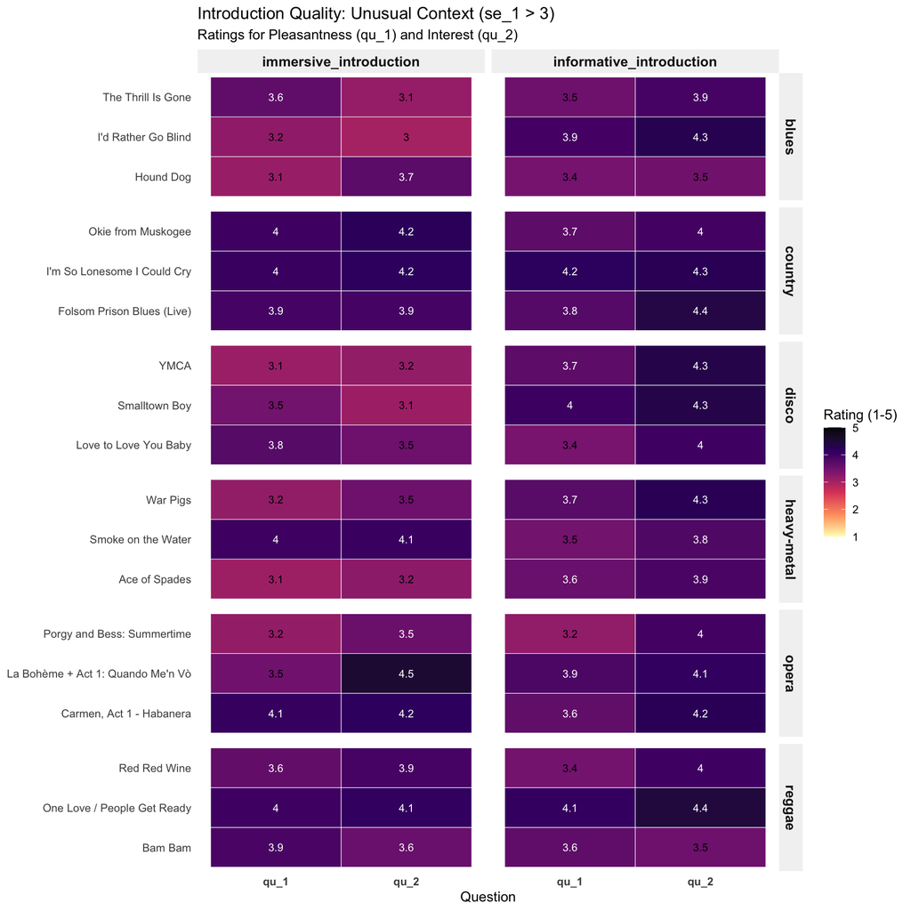

```r
# 1. Prepare Data: Filter for High Unusualness
quality_unusual <- data |>
  # Exclude control group and filter for Unusual condition
  filter(intro != "no_introduction", se_1 > 3) |>

  # Select and Pivot
  dplyr::select(intro, genre, name, qu_1, qu_2) |>
  pivot_longer(
    cols = c(qu_1, qu_2),
    names_to = "question",
    values_to = "score"
  ) |>

  # Aggregate Mean Scores
  group_by(intro, genre, name, question) |>
  summarise(mean_score = mean(as.numeric(score), na.rm = TRUE), .groups = "drop")

# 2. Plot Heatmap
ggplot(quality_unusual, aes(x = question, y = name, fill = mean_score)) +
  geom_tile(color = "white") +

  # Add score labels with dynamic contrast color
  geom_text(
    aes(
      label = round(mean_score, 1),
      color = ifelse(mean_score > 3.5, "white", "black")
    ),
    size = 3
  ) +
  scale_color_identity() +

  # Facet: Rows by Genre, Columns by Introduction Type
  facet_grid(genre ~ intro, scales = "free_y", space = "free_y") +

  # Color Scale
  scale_fill_viridis_c(
    option = "magma",
    direction = -1,
    limits = c(1, 5),
    name = "Rating (1-5)"
  ) +

  # Labels
  labs(
    title = "Introduction Quality: Unusual Context (se_1 > 3)",
    subtitle = "Ratings for Pleasantness (qu_1) and Interest (qu_2)",
    x = "Question",
    y = NULL
  ) +
  theme_minimal() +
  theme(
    panel.grid = element_blank(),
    strip.text = element_text(face = "bold", size = 11),
    strip.background = element_rect(fill = "grey95", color = NA),
    axis.text.x = element_text(face = "bold")
  )
```

Heatmap **Inside Typical Preferences**

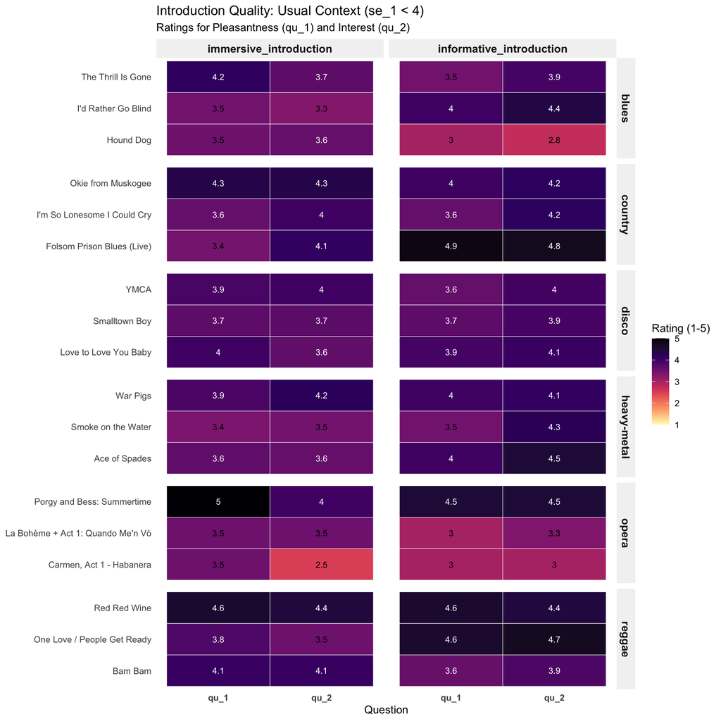

```r
# 1. Prepare Data: Filter for Low Unusualness (Usual)
quality_usual <- data |>
  filter(intro != "no_introduction", se_1 < 4) |>

  dplyr::select(intro, genre, name, qu_1, qu_2) |>
  pivot_longer(
    cols = c(qu_1, qu_2),
    names_to = "question",
    values_to = "score"
  ) |>

  group_by(intro, genre, name, question) |>
  summarise(mean_score = mean(as.numeric(score), na.rm = TRUE), .groups = "drop")

# 2. Plot Heatmap
ggplot(quality_usual, aes(x = question, y = name, fill = mean_score)) +
  geom_tile(color = "white") +

  geom_text(
    aes(
      label = round(mean_score, 1),
      color = ifelse(mean_score > 3.5, "white", "black")
    ),
    size = 3
  ) +
  scale_color_identity() +

  facet_grid(genre ~ intro, scales = "free_y", space = "free_y") +

  scale_fill_viridis_c(
    option = "magma",
    direction = -1,
    limits = c(1, 5),
    name = "Rating (1-5)"
  ) +

  labs(
    title = "Introduction Quality: Usual Context (se_1 < 4)",
    subtitle = "Ratings for Pleasantness (qu_1) and Interest (qu_2)",
    x = "Question",
    y = NULL
  ) +
  theme_minimal() +
  theme(
    panel.grid = element_blank(),
    strip.text = element_text(face = "bold", size = 11),
    strip.background = element_rect(fill = "grey95", color = NA),
    axis.text.x = element_text(face = "bold")
  )
```

## 4.1. Quality of introductions as a confounder of the effect of introduction on TBS and TDS

Let’s check whether quality is a good predictor of TBS and TDS. This implies that we will focus on immersive and informative introductions alone since we don’t have quality ratings for no_introduction condition of course.

```r
tbs_intro <- tbs_data |>
  filter(intro == "immersive_introduction" | intro == "informative_introduction")

tds_intro <- tds_data |>
  filter(intro == "immersive_introduction" | intro == "informative_introduction")
```

Next, we will start with a baseline model to see whether here we can actually see a difference between the effect of immersive and informative introductions:

```r
# 1. Fit the Logistic Model (Bernoulli)
fit_tbs_intro <- brm(
  formula = tbs ~ intro + (1 | name) + (1 | sess_id),
  data = tbs_intro,
  family = bernoulli(link = "logit"),
  backend = "cmdstanr",
  chains = 4,
  cores = 4,
  iter = 2000,
  seed = 42
)
```

[output not shown]

[output cut: 43 more lines]

[output not shown]

```r
# 2. Check the Summary
summary(fit_tbs_intro)
```

```
 Family: bernoulli
  Links: mu = logit
Formula: tbs ~ intro + (1 | name) + (1 | sess_id)
   Data: tbs_intro (Number of observations: 550)
  Draws: 4 chains, each with iter = 2000; warmup = 1000; thin = 1;
         total post-warmup draws = 4000

Multilevel Hyperparameters:
~name (Number of levels: 18)
              Estimate Est.Error l-95% CI u-95% CI Rhat Bulk_ESS Tail_ESS
sd(Intercept)     0.53      0.21     0.15     1.00 1.00      997     1168

~sess_id (Number of levels: 328)
              Estimate Est.Error l-95% CI u-95% CI Rhat Bulk_ESS Tail_ESS
sd(Intercept)     1.73      0.32     1.13     2.41 1.00      819     1460

Regression Coefficients:
                              Estimate Est.Error l-95% CI u-95% CI Rhat
Intercept                        -0.30      0.23    -0.77     0.15 1.00
introinformative_introduction     0.47      0.23     0.02     0.92 1.00
                              Bulk_ESS Tail_ESS
Intercept                         2269     2535
introinformative_introduction     3988     2797

Draws were sampled using sample(hmc). For each parameter, Bulk_ESS
and Tail_ESS are effective sample size measures, and Rhat is the potential
scale reduction factor on split chains (at convergence, Rhat = 1).
```

Small significant significant difference.

Same for TDS:

```r
# 1. Fit the Logistic Model (Bernoulli)
fit_tds_intro <- brm(
  formula = tds ~ intro + (1 | name) + (1 | sess_id),
  data = tds_intro,
  family = bernoulli(link = "logit"),
  backend = "cmdstanr",
  chains = 4,
  cores = 4,
  iter = 2000,
  seed = 42
)
```

[output not shown]

[output cut: 43 more lines]

[output not shown]

```r
# 2. Check the Summary
summary(fit_tds_intro)
```

```
 Family: bernoulli
  Links: mu = logit
Formula: tds ~ intro + (1 | name) + (1 | sess_id)
   Data: tds_intro (Number of observations: 354)
  Draws: 4 chains, each with iter = 2000; warmup = 1000; thin = 1;
         total post-warmup draws = 4000

Multilevel Hyperparameters:
~name (Number of levels: 18)
              Estimate Est.Error l-95% CI u-95% CI Rhat Bulk_ESS Tail_ESS
sd(Intercept)     0.44      0.25     0.03     1.02 1.00      888     1630

~sess_id (Number of levels: 230)
              Estimate Est.Error l-95% CI u-95% CI Rhat Bulk_ESS Tail_ESS
sd(Intercept)     1.24      0.48     0.27     2.23 1.01      425      610

Regression Coefficients:
                              Estimate Est.Error l-95% CI u-95% CI Rhat
Intercept                        -0.81      0.27    -1.37    -0.33 1.00
introinformative_introduction     1.01      0.32     0.44     1.70 1.00
                              Bulk_ESS Tail_ESS
Intercept                         1556     1699
introinformative_introduction     1198     1826

Draws were sampled using sample(hmc). For each parameter, Bulk_ESS
and Tail_ESS are effective sample size measures, and Rhat is the potential
scale reduction factor on split chains (at convergence, Rhat = 1).
```

Bigger significant difference.

Now, we’ll see whether the perceived quality of the introductions is predictive for experiencing TBS and TDS. We start with TBS:

```r
# 1. Fit the Logistic Model (Bernoulli)
fit_tbs_intro_qu <- brm(
  formula = tbs ~ intro + qu_1 + qu_2 + qu_3 + (1 | name) + (1 | sess_id),
  data = tbs_intro,
  family = bernoulli(link = "logit"),
  backend = "cmdstanr",
  chains = 4,
  cores = 4,
  iter = 2000,
  seed = 42
)
```

[output not shown]

[output cut: 43 more lines]

[output not shown]

```r
# 2. Check the Summary
summary(fit_tbs_intro_qu)
```

```
 Family: bernoulli
  Links: mu = logit
Formula: tbs ~ intro + qu_1 + qu_2 + qu_3 + (1 | name) + (1 | sess_id)
   Data: tbs_intro (Number of observations: 550)
  Draws: 4 chains, each with iter = 2000; warmup = 1000; thin = 1;
         total post-warmup draws = 4000

Multilevel Hyperparameters:
~name (Number of levels: 18)
              Estimate Est.Error l-95% CI u-95% CI Rhat Bulk_ESS Tail_ESS
sd(Intercept)     0.45      0.23     0.06     0.95 1.01      862     1569

~sess_id (Number of levels: 328)
              Estimate Est.Error l-95% CI u-95% CI Rhat Bulk_ESS Tail_ESS
sd(Intercept)     1.51      0.34     0.88     2.21 1.01      685     1318

Regression Coefficients:
                              Estimate Est.Error l-95% CI u-95% CI Rhat
Intercept                        -3.95      0.83    -5.67    -2.40 1.00
introinformative_introduction     0.27      0.23    -0.17     0.72 1.00
qu_1                              0.30      0.15     0.01     0.60 1.00
qu_2                              0.69      0.19     0.35     1.07 1.00
qu_3                             -0.01      0.18    -0.37     0.36 1.00
                              Bulk_ESS Tail_ESS
Intercept                         2088     2252
introinformative_introduction     4309     2835
qu_1                              2637     3052
qu_2                              2186     2045
qu_3                              3050     2674

Draws were sampled using sample(hmc). For each parameter, Bulk_ESS
and Tail_ESS are effective sample size measures, and Rhat is the potential
scale reduction factor on split chains (at convergence, Rhat = 1).
```

- qu_1 has a small significant effect
- qu_2 has a bigger signficant effect

```r
# 1. Fit the Logistic Model (Bernoulli)
fit_tds_intro_qu <- brm(
  formula = tds ~ intro + qu_1 + qu_2 + qu_3 + (1 | name) + (1 | sess_id),
  data = tds_intro,
  family = bernoulli(link = "logit"),
  backend = "cmdstanr",
  chains = 4,
  cores = 4,
  iter = 2000,
  seed = 42
)
```

[output not shown]

[output cut: 43 more lines]

[output not shown]

```r
# 2. Check the Summary
summary(fit_tds_intro_qu)
```

```
 Family: bernoulli
  Links: mu = logit
Formula: tds ~ intro + qu_1 + qu_2 + qu_3 + (1 | name) + (1 | sess_id)
   Data: tds_intro (Number of observations: 354)
  Draws: 4 chains, each with iter = 2000; warmup = 1000; thin = 1;
         total post-warmup draws = 4000

Multilevel Hyperparameters:
~name (Number of levels: 18)
              Estimate Est.Error l-95% CI u-95% CI Rhat Bulk_ESS Tail_ESS
sd(Intercept)     0.43      0.26     0.03     1.02 1.00      963     1512

~sess_id (Number of levels: 230)
              Estimate Est.Error l-95% CI u-95% CI Rhat Bulk_ESS Tail_ESS
sd(Intercept)     1.46      0.49     0.52     2.46 1.00      399      537

Regression Coefficients:
                              Estimate Est.Error l-95% CI u-95% CI Rhat
Intercept                        -3.67      1.08    -5.96    -1.71 1.00
introinformative_introduction     0.88      0.33     0.25     1.57 1.00
qu_1                              0.23      0.23    -0.21     0.68 1.00
qu_2                              0.94      0.29     0.41     1.58 1.00
qu_3                             -0.41      0.28    -0.97     0.11 1.00
                              Bulk_ESS Tail_ESS
Intercept                         1534     2384
introinformative_introduction     1363     2407
qu_1                              2079     2331
qu_2                              1681     1670
qu_3                              2271     2344

Draws were sampled using sample(hmc). For each parameter, Bulk_ESS
and Tail_ESS are effective sample size measures, and Rhat is the potential
scale reduction factor on split chains (at convergence, Rhat = 1).
```

Only qu_2 is significant.

Let’s illustrate what happens with the effect of intro when we consider different levels of quality:

**qu_2 < 3**

```r
# Create a new dataframe 'tbs_lq' (Low Quality or Control)
tbs_lq <- tbs_data |>
  dplyr::filter(
    (qu_2 < 3 | is.na(qu_2))
  )

# Check how many rows were dropped
nrow(tbs_data) - nrow(tbs_lq)
```

```
[1] 485
```

```r
# Create a new dataframe 'unfam_df_hq' (Low Quality or Control)
tds_lq <- tds_data |>
  dplyr::filter(
    (qu_2 < 3 | is.na(qu_2))
  )

# Check how many rows were dropped
nrow(tds_data) - nrow(tds_lq)
```

```
[1] 308
```

```r
# 1. Fit the Logistic Model (Bernoulli)
fit_tbs_intro_lq <- brm(
  formula = tbs ~ intro + (1 | name) + (1 | sess_id),
  data = tbs_lq,
  family = bernoulli(link = "logit"),
  backend = "cmdstanr",
  chains = 4,
  cores = 4,
  iter = 2000,
  seed = 42
)
```

[output not shown]

[output cut: 43 more lines]

[output not shown]

```r
# 2. Check the Summary
summary(fit_tbs_intro_lq)
```

```
 Family: bernoulli
  Links: mu = logit
Formula: tbs ~ intro + (1 | name) + (1 | sess_id)
   Data: tbs_lq (Number of observations: 336)
  Draws: 4 chains, each with iter = 2000; warmup = 1000; thin = 1;
         total post-warmup draws = 4000

Multilevel Hyperparameters:
~name (Number of levels: 18)
              Estimate Est.Error l-95% CI u-95% CI Rhat Bulk_ESS Tail_ESS
sd(Intercept)     0.62      0.42     0.03     1.61 1.00      670     1200

~sess_id (Number of levels: 286)
              Estimate Est.Error l-95% CI u-95% CI Rhat Bulk_ESS Tail_ESS
sd(Intercept)     2.36      1.22     0.40     5.25 1.02      198      320

Regression Coefficients:
                              Estimate Est.Error l-95% CI u-95% CI Rhat
Intercept                        -1.07      0.47    -2.27    -0.41 1.01
introimmersive_introduction      -0.62      0.65    -1.83     0.73 1.00
introinformative_introduction    -2.10      1.14    -4.69    -0.22 1.00
                              Bulk_ESS Tail_ESS
Intercept                          387      776
introimmersive_introduction       2780     1492
introinformative_introduction     1234     1621

Draws were sampled using sample(hmc). For each parameter, Bulk_ESS
and Tail_ESS are effective sample size measures, and Rhat is the potential
scale reduction factor on split chains (at convergence, Rhat = 1).
```

```r
# 1. Fit the Logistic Model (Bernoulli)
fit_tds_intro_lq <- brm(
  formula = tds ~ intro + (1 | name) + (1 | sess_id),
  data = tds_lq,
  family = bernoulli(link = "logit"),
  backend = "cmdstanr",
  chains = 4,
  cores = 4,
  iter = 2000,
  seed = 42
)
```

[output not shown]

[output cut: 43 more lines]

[output not shown]

```r
# 2. Check the Summary
summary(fit_tds_intro_lq)
```

```
 Family: bernoulli
  Links: mu = logit
Formula: tds ~ intro + (1 | name) + (1 | sess_id)
   Data: tds_lq (Number of observations: 227)
  Draws: 4 chains, each with iter = 2000; warmup = 1000; thin = 1;
         total post-warmup draws = 4000

Multilevel Hyperparameters:
~name (Number of levels: 18)
              Estimate Est.Error l-95% CI u-95% CI Rhat Bulk_ESS Tail_ESS
sd(Intercept)     0.54      0.40     0.03     1.53 1.00      960     1720

~sess_id (Number of levels: 192)
              Estimate Est.Error l-95% CI u-95% CI Rhat Bulk_ESS Tail_ESS
sd(Intercept)     0.97      0.76     0.03     2.80 1.01      311      414

Regression Coefficients:
                              Estimate Est.Error l-95% CI u-95% CI Rhat
Intercept                        -1.88      0.47    -3.04    -1.21 1.01
introimmersive_introduction      -0.21      0.64    -1.49     1.01 1.00
introinformative_introduction    -0.42      0.95    -2.46     1.31 1.00
                              Bulk_ESS Tail_ESS
Intercept                          486      678
introimmersive_introduction       3355     1785
introinformative_introduction     4175     2458

Draws were sampled using sample(hmc). For each parameter, Bulk_ESS
and Tail_ESS are effective sample size measures, and Rhat is the potential
scale reduction factor on split chains (at convergence, Rhat = 1).
```

**qu_2 [2-4]**

```r
# Create a new dataframe (Medium Quality or Control)
tbs_avg <- tbs_data |>
  dplyr::filter(
    (qu_2 < 5 & qu_2 > 1 | is.na(qu_2))
  )

# Check how many rows were dropped
nrow(tbs_data) - nrow(tbs_avg)
```

```
[1] 198
```

```r
# Create a new dataframe (Medium Quality or Control)
tds_avg <- tds_data |>
  dplyr::filter(
    (qu_2 < 5 & qu_2 > 1 | is.na(qu_2))
  )

# Check how many rows were dropped
nrow(tds_data) - nrow(tds_avg)
```

```
[1] 143
```

```r
# 1. Fit the Logistic Model for TBS (Bernoulli)
fit_tbs_intro_avg <- brm(
  formula = tbs ~ intro + (1 | name) + (1 | sess_id),
  data = tbs_avg,
  family = bernoulli(link = "logit"),
  backend = "cmdstanr",
  chains = 4,
  cores = 4,
  iter = 2000,
  seed = 42
)
```

[output not shown]

[output cut: 43 more lines]

[output not shown]

```r
# 2. Check the Summary
summary(fit_tbs_intro_avg)
```

```
 Family: bernoulli
  Links: mu = logit
Formula: tbs ~ intro + (1 | name) + (1 | sess_id)
   Data: tbs_avg (Number of observations: 623)
  Draws: 4 chains, each with iter = 2000; warmup = 1000; thin = 1;
         total post-warmup draws = 4000

Multilevel Hyperparameters:
~name (Number of levels: 18)
              Estimate Est.Error l-95% CI u-95% CI Rhat Bulk_ESS Tail_ESS
sd(Intercept)     0.43      0.18     0.08     0.83 1.00     1018      931

~sess_id (Number of levels: 322)
              Estimate Est.Error l-95% CI u-95% CI Rhat Bulk_ESS Tail_ESS
sd(Intercept)     1.22      0.25     0.74     1.76 1.00      791     1461

Regression Coefficients:
                              Estimate Est.Error l-95% CI u-95% CI Rhat
Intercept                        -0.73      0.21    -1.16    -0.33 1.00
introimmersive_introduction       0.19      0.25    -0.28     0.66 1.00
introinformative_introduction     0.39      0.25    -0.10     0.89 1.00
                              Bulk_ESS Tail_ESS
Intercept                         2492     2795
introimmersive_introduction       4183     3408
introinformative_introduction     4052     2904

Draws were sampled using sample(hmc). For each parameter, Bulk_ESS
and Tail_ESS are effective sample size measures, and Rhat is the potential
scale reduction factor on split chains (at convergence, Rhat = 1).
```

```r
# 1. Fit the Logistic Model for TDS (Bernoulli)
fit_tds_intro_avg <- brm(
  formula = tds ~ intro + (1 | name) + (1 | sess_id),
  data = tds_avg,
  family = bernoulli(link = "logit"),
  backend = "cmdstanr",
  chains = 4,
  cores = 4,
  iter = 2000,
  seed = 42
)
```

[output not shown]

[output cut: 43 more lines]

[output not shown]

```r
# 2. Check the Summary
summary(fit_tds_intro_avg)
```

```
 Family: bernoulli
  Links: mu = logit
Formula: tds ~ intro + (1 | name) + (1 | sess_id)
   Data: tds_avg (Number of observations: 392)
  Draws: 4 chains, each with iter = 2000; warmup = 1000; thin = 1;
         total post-warmup draws = 4000

Multilevel Hyperparameters:
~name (Number of levels: 18)
              Estimate Est.Error l-95% CI u-95% CI Rhat Bulk_ESS Tail_ESS
sd(Intercept)     0.35      0.24     0.02     0.90 1.00     1196     2136

~sess_id (Number of levels: 226)
              Estimate Est.Error l-95% CI u-95% CI Rhat Bulk_ESS Tail_ESS
sd(Intercept)     1.56      0.49     0.66     2.59 1.01      369      778

Regression Coefficients:
                              Estimate Est.Error l-95% CI u-95% CI Rhat
Intercept                        -2.11      0.40    -2.96    -1.45 1.00
introimmersive_introduction       1.04      0.37     0.39     1.80 1.00
introinformative_introduction     1.81      0.46     0.97     2.81 1.00
                              Bulk_ESS Tail_ESS
Intercept                          694     1714
introimmersive_introduction       1694     1725
introinformative_introduction      933     1846

Draws were sampled using sample(hmc). For each parameter, Bulk_ESS
and Tail_ESS are effective sample size measures, and Rhat is the potential
scale reduction factor on split chains (at convergence, Rhat = 1).
```

For TDS, the informative intros already have a significant positive effect.

**qu_2 > 3**

```r
# Create a new dataframe (High Quality or Control)
tbs_high <- tbs_data |>
  dplyr::filter(
    (qu_2 > 3 | is.na(qu_2))
  )

# Check how many rows were dropped
nrow(tbs_data) - nrow(tbs_high)
```

```
[1] 138
```

```r
# Create a new dataframe (High Quality or Control)
tds_high <- tds_data |>
  dplyr::filter(
    (qu_2 > 3 | is.na(qu_2))
  )

# Check how many rows were dropped
nrow(tds_data) - nrow(tds_high)
```

```
[1] 96
```

```r
# 1. Fit the Logistic Model for TBS (Bernoulli)
fit_tbs_intro_high <- brm(
  formula = tbs ~ intro + (1 | name) + (1 | sess_id),
  data = tbs_high,
  family = bernoulli(link = "logit"),
  backend = "cmdstanr",
  chains = 4,
  cores = 4,
  iter = 2000,
  seed = 42
)
```

[output not shown]

[output cut: 43 more lines]

[output not shown]

```r
# 2. Check the Summary
summary(fit_tbs_intro_high)
```

```
 Family: bernoulli
  Links: mu = logit
Formula: tbs ~ intro + (1 | name) + (1 | sess_id)
   Data: tbs_high (Number of observations: 683)
  Draws: 4 chains, each with iter = 2000; warmup = 1000; thin = 1;
         total post-warmup draws = 4000

Multilevel Hyperparameters:
~name (Number of levels: 18)
              Estimate Est.Error l-95% CI u-95% CI Rhat Bulk_ESS Tail_ESS
sd(Intercept)     0.38      0.18     0.06     0.75 1.00      884      778

~sess_id (Number of levels: 327)
              Estimate Est.Error l-95% CI u-95% CI Rhat Bulk_ESS Tail_ESS
sd(Intercept)     1.21      0.22     0.80     1.65 1.00      873     1657

Regression Coefficients:
                              Estimate Est.Error l-95% CI u-95% CI Rhat
Intercept                        -0.73      0.19    -1.12    -0.36 1.00
introimmersive_introduction       0.79      0.23     0.35     1.26 1.00
introinformative_introduction     1.22      0.23     0.79     1.68 1.00
                              Bulk_ESS Tail_ESS
Intercept                         2705     2558
introimmersive_introduction       3711     2819
introinformative_introduction     3117     3063

Draws were sampled using sample(hmc). For each parameter, Bulk_ESS
and Tail_ESS are effective sample size measures, and Rhat is the potential
scale reduction factor on split chains (at convergence, Rhat = 1).
```

```r
# 1. Fit the Logistic Model for TDS (Bernoulli)
fit_tds_intro_high <- brm(
  formula = tds ~ intro + (1 | name) + (1 | sess_id),
  data = tds_high,
  family = bernoulli(link = "logit"),
  backend = "cmdstanr",
  chains = 4,
  cores = 4,
  iter = 2000,
  seed = 42
)
```

[output not shown]

[output cut: 43 more lines]

[output not shown]

```r
# 2. Check the Summary
summary(fit_tds_intro_high)
```

```
 Family: bernoulli
  Links: mu = logit
Formula: tds ~ intro + (1 | name) + (1 | sess_id)
   Data: tds_high (Number of observations: 439)
  Draws: 4 chains, each with iter = 2000; warmup = 1000; thin = 1;
         total post-warmup draws = 4000

Multilevel Hyperparameters:
~name (Number of levels: 18)
              Estimate Est.Error l-95% CI u-95% CI Rhat Bulk_ESS Tail_ESS
sd(Intercept)     0.29      0.19     0.01     0.72 1.00     1213     1700

~sess_id (Number of levels: 240)
              Estimate Est.Error l-95% CI u-95% CI Rhat Bulk_ESS Tail_ESS
sd(Intercept)     1.12      0.37     0.37     1.85 1.01      609      941

Regression Coefficients:
                              Estimate Est.Error l-95% CI u-95% CI Rhat
Intercept                        -1.87      0.30    -2.49    -1.33 1.00
introimmersive_introduction       1.63      0.35     0.97     2.35 1.00
introinformative_introduction     2.36      0.39     1.64     3.17 1.00
                              Bulk_ESS Tail_ESS
Intercept                         1423     1993
introimmersive_introduction       2040     2420
introinformative_introduction     1225     2129

Draws were sampled using sample(hmc). For each parameter, Bulk_ESS
and Tail_ESS are effective sample size measures, and Rhat is the potential
scale reduction factor on split chains (at convergence, Rhat = 1).
```

In this condition, all introduction styles have highly positive significant effects.

# 5. The effect of introductions on liking, disliking, and time listened

## 5.1. The effect on liking

Let’s check the likes per intro category:

```r
library(dplyr)
library(gt)

# 1. Prepare the Summary Data
like_summary <- tbs_data |>
  # Group by the introduction condition
  group_by(intro) |>
  summarise(
    n_total = n(),
    # Count how many said TRUE (assuming TRUE = 1 and FALSE = 0 in boolean math)
    n_liked = sum(like == TRUE, na.rm = TRUE),
    # Calculate the percentage
    pct_liked = mean(like == TRUE, na.rm = TRUE)
  ) |>
  ungroup()

# 2. Create the Publication-Ready Table
like_table_tbs <- like_summary |>
  gt() |>

  # --- FORMATTING NUMBERS ---
  fmt_percent(
    columns = pct_liked,
    decimals = 1
  ) |>

  # --- LABELS ---
  cols_label(
    intro = "Introduction Type",
    n_total = "Total (N)",
    n_liked = "Count (Liked)",
    pct_liked = "% Liked"
  ) |>

  # --- RENAMING INTROS ---
  text_transform(
    locations = cells_body(columns = intro),
    fn = function(x) {
      case_when(
        x == "no_intro" ~ "No Introduction",
        x == "introimmersive_introduction" ~ "Immersive Introduction",
        x == "introinformative_introduction" ~ "Informative Introduction",
        TRUE ~ x
      )
    }
  ) |>

  # --- ALIGNMENT ---
  cols_align(align = "left", columns = intro) |>
  cols_align(align = "center", columns = c(n_total, n_liked, pct_liked)) |>

  # --- STYLING ---
  tab_header(
    title = "Song Liking by Introduction Condition",
    subtitle = "Frequency and percentage of participants who liked the song"
  ) |>

  opt_table_lines(extent = "default") |>
  tab_options(
    heading.align = "left",
    column_labels.font.weight = "bold",
    table.border.top.width = px(2),
    table.border.bottom.width = px(2)
  )

like_table_tbs
```

Song Liking by Introduction Condition

Frequency and percentage of participants who liked the song

| Introduction Type | Total (N) | Count (Liked) | % Liked |
| --- | --- | --- | --- |
| no_introduction | 271 | 91 | 33.6% |
| immersive_introduction | 271 | 103 | 38.0% |
| informative_introduction | 279 | 110 | 39.4% |

```r
library(dplyr)
library(gt)

# 1. Prepare the Summary Data
like_summary <- tds_data |>
  # Group by the introduction condition
  group_by(intro) |>
  summarise(
    n_total = n(),
    # Count how many said TRUE (assuming TRUE = 1 and FALSE = 0 in boolean math)
    n_liked = sum(like == TRUE, na.rm = TRUE),
    # Calculate the percentage
    pct_liked = mean(like == TRUE, na.rm = TRUE)
  ) |>
  ungroup()

# 2. Create the Publication-Ready Table
like_table_tds <- like_summary |>
  gt() |>

  # --- FORMATTING NUMBERS ---
  fmt_percent(
    columns = pct_liked,
    decimals = 1
  ) |>

  # --- LABELS ---
  cols_label(
    intro = "Introduction Type",
    n_total = "Total (N)",
    n_liked = "Count (Liked)",
    pct_liked = "% Liked"
  ) |>

  # --- RENAMING INTROS ---
  text_transform(
    locations = cells_body(columns = intro),
    fn = function(x) {
      case_when(
        x == "no_intro" ~ "No Introduction",
        x == "introimmersive_introduction" ~ "Immersive Introduction",
        x == "introinformative_introduction" ~ "Informative Introduction",
        TRUE ~ x
      )
    }
  ) |>

  # --- ALIGNMENT ---
  cols_align(align = "left", columns = intro) |>
  cols_align(align = "center", columns = c(n_total, n_liked, pct_liked)) |>

  # --- STYLING ---
  tab_header(
    title = "Song Liking by Introduction Condition",
    subtitle = "Frequency and percentage of participants who liked the song"
  ) |>

  opt_table_lines(extent = "default") |>
  tab_options(
    heading.align = "left",
    column_labels.font.weight = "bold",
    table.border.top.width = px(2),
    table.border.bottom.width = px(2)
  )

like_table_tds
```

Song Liking by Introduction Condition

Frequency and percentage of participants who liked the song

| Introduction Type | Total (N) | Count (Liked) | % Liked |
| --- | --- | --- | --- |
| no_introduction | 181 | 111 | 61.3% |
| immersive_introduction | 181 | 121 | 66.9% |
| informative_introduction | 173 | 98 | 56.6% |

These differences are not that impressive.

## 5.2. The effect on disliking

Let’s check the dislikes per intro category:

```r
# 1. Prepare the Summary Data
dislike_summary <- tbs_data |>
  # Group by the introduction condition
  group_by(intro) |>
  summarise(
    n_total = n(),
    # Count how many said TRUE (assuming TRUE = 1 and FALSE = 0)
    n_disliked = sum(dislike == TRUE, na.rm = TRUE),
    # Calculate the percentage
    pct_disliked = mean(dislike == TRUE, na.rm = TRUE)
  ) |>
  ungroup()

# 2. Create the Publication-Ready Table
dislike_table_tbs <- dislike_summary |>
  gt() |>

  # --- FORMATTING NUMBERS ---
  fmt_percent(
    columns = pct_disliked,
    decimals = 1
  ) |>

  # --- LABELS ---
  cols_label(
    intro = "Introduction Type",
    n_total = "Total (N)",
    n_disliked = "Count (Disliked)",
    pct_disliked = "% Disliked"
  ) |>

  # --- RENAMING INTROS ---
  text_transform(
    locations = cells_body(columns = intro),
    fn = function(x) {
      case_when(
        x == "no_intro" ~ "No Introduction",
        x == "introimmersive_introduction" ~ "Immersive Introduction",
        x == "introinformative_introduction" ~ "Informative Introduction",
        TRUE ~ x
      )
    }
  ) |>

  # --- ALIGNMENT ---
  cols_align(align = "left", columns = intro) |>
  cols_align(align = "center", columns = c(n_total, n_disliked, pct_disliked)) |>

  # --- STYLING ---
  tab_header(
    title = "Song Disliking by Introduction Condition",
    subtitle = "Frequency and percentage of participants who disliked the song"
  ) |>

  opt_table_lines(extent = "default") |>
  tab_options(
    heading.align = "left",
    column_labels.font.weight = "bold",
    table.border.top.width = px(2),
    table.border.bottom.width = px(2)
  )

dislike_table_tbs
```

Song Disliking by Introduction Condition

Frequency and percentage of participants who disliked the song

| Introduction Type | Total (N) | Count (Disliked) | % Disliked |
| --- | --- | --- | --- |
| no_introduction | 271 | 41 | 15.1% |
| immersive_introduction | 271 | 32 | 11.8% |
| informative_introduction | 279 | 26 | 9.3% |

```r
# 1. Prepare the Summary Data
dislike_summary <- tds_data |>
  # Group by the introduction condition
  group_by(intro) |>
  summarise(
    n_total = n(),
    # Count how many said TRUE (assuming TRUE = 1 and FALSE = 0)
    n_disliked = sum(dislike == TRUE, na.rm = TRUE),
    # Calculate the percentage
    pct_disliked = mean(dislike == TRUE, na.rm = TRUE)
  ) |>
  ungroup()

# 2. Create the Publication-Ready Table
dislike_table_tds <- dislike_summary |>
  gt() |>

  # --- FORMATTING NUMBERS ---
  fmt_percent(
    columns = pct_disliked,
    decimals = 1
  ) |>

  # --- LABELS ---
  cols_label(
    intro = "Introduction Type",
    n_total = "Total (N)",
    n_disliked = "Count (Disliked)",
    pct_disliked = "% Disliked"
  ) |>

  # --- RENAMING INTROS ---
  text_transform(
    locations = cells_body(columns = intro),
    fn = function(x) {
      case_when(
        x == "no_intro" ~ "No Introduction",
        x == "introimmersive_introduction" ~ "Immersive Introduction",
        x == "introinformative_introduction" ~ "Informative Introduction",
        TRUE ~ x
      )
    }
  ) |>

  # --- ALIGNMENT ---
  cols_align(align = "left", columns = intro) |>
  cols_align(align = "center", columns = c(n_total, n_disliked, pct_disliked)) |>

  # --- STYLING ---
  tab_header(
    title = "Song Disliking by Introduction Condition",
    subtitle = "Frequency and percentage of participants who disliked the song"
  ) |>

  opt_table_lines(extent = "default") |>
  tab_options(
    heading.align = "left",
    column_labels.font.weight = "bold",
    table.border.top.width = px(2),
    table.border.bottom.width = px(2)
  )

dislike_table_tds
```

Song Disliking by Introduction Condition

Frequency and percentage of participants who disliked the song

| Introduction Type | Total (N) | Count (Disliked) | % Disliked |
| --- | --- | --- | --- |
| no_introduction | 181 | 5 | 2.8% |
| immersive_introduction | 181 | 0 | 0.0% |
| informative_introduction | 173 | 5 | 2.9% |

Again, the difference is quite small and probably not significant. The percentage of disliked songs here is quite small, which makes sense bcs they are listening to their preferences.

# 6. The effect of experiencing TBS and TDS on satisfaction

Here, we will look whether experiencing more TBS or TDS in a session leads to more satisfaction. - **sa_1:** “I enjoyed listening to the music” - **sa_2:** “I would like to listen to more music from this genre”

To assess this relationship, we need to pivot our dataframe to a wide format and add a count variable of the serendipity variables.

We will only focus on those participants that have scores for all three songs, because in that way we can compare whether experiencing tbs on 0,1,2, or 3 songs leads to higher satisfaction scores.

```r
# Create Wide Data for TBS (High Unusualness Items)
wide_df_tbs <- tbs_data |>
  # Re-index trials strictly within this subset (1st, 2nd, 3rd unusual song)
  group_by(sess_id) |>
  mutate(trial_num = row_number()) |>
  ungroup() |>

  # Pivot ALL variable columns, including 'intro'
  pivot_wider(
    id_cols = c(sess_id, genre, fsat_01, fsat_02),
    names_from = trial_num,
    values_from = c(tbs, like, dislike, dur, intro),
    names_glue = "{.value}_{trial_num}"
  ) |>

  # STRICT FILTER: Keep only sessions with at least 3 valid unusual songs
  tidyr::drop_na(tbs_1, tbs_2, tbs_3) |>

  # Calculate Session-Level Summary (Count of successes 0-3)
  rowwise() |>
  mutate(
    tbs_count = sum(c(tbs_1, tbs_2, tbs_3), na.rm = TRUE),
    like_count = sum(c(like_1, like_2, like_3), na.rm = TRUE)
  ) |>
  ungroup()

# Inspect the structure
glimpse(wide_df_tbs)
```

```
Rows: 200
Columns: 21
$ sess_id    <dbl> 1388396358, 430299143, 1822909147, 906649414, 1031483611, 1…
$ genre      <chr> "reggae", "heavy-metal", "opera", "blues", "country", "coun…
$ fsat_01    <dbl> 4, 3, 4, 3, 5, 3, 5, 4, 5, 4, 5, 3, 5, 4, 5, 5, 5, 4, 2, 5,…
$ fsat_02    <dbl> 5, 3, 3, 2, 5, 3, 3, 5, 5, 4, 1, 3, 5, 2, 3, 5, 4, 3, 1, 5,…
$ tbs_1      <dbl> 1, 0, 1, 0, 0, 0, 0, 1, 1, 1, 0, 0, 1, 0, 1, 1, 0, 0, 0, 0,…
$ tbs_2      <dbl> 1, 1, 0, 0, 1, 0, 0, 0, 1, 0, 0, 0, 1, 1, 0, 1, 1, 0, 1, 0,…
$ tbs_3      <dbl> 0, 0, 1, 0, 1, 0, 0, 1, 1, 0, 1, 1, 1, 1, 0, 1, 0, 0, 0, 1,…
$ like_1     <lgl> TRUE, FALSE, FALSE, FALSE, TRUE, FALSE, FALSE, FALSE, TRUE,…
$ like_2     <lgl> FALSE, TRUE, FALSE, FALSE, TRUE, FALSE, FALSE, FALSE, TRUE,…
$ like_3     <lgl> FALSE, FALSE, FALSE, FALSE, TRUE, FALSE, FALSE, TRUE, TRUE,…
$ dislike_1  <lgl> FALSE, FALSE, FALSE, FALSE, FALSE, FALSE, FALSE, FALSE, FAL…
$ dislike_2  <lgl> FALSE, FALSE, FALSE, FALSE, FALSE, FALSE, FALSE, FALSE, FAL…
$ dislike_3  <lgl> TRUE, FALSE, FALSE, FALSE, FALSE, FALSE, FALSE, FALSE, FALS…
$ dur_1      <dbl> 175663, 31802, 166640, 80517, 42227, 125123, 321042, 156741…
$ dur_2      <dbl> 321830, 172130, 152100, 59527, 42968, 68994, 196593, 111052…
$ dur_3      <dbl> 197318, 34145, 269443, 65358, 32085, 73770, 174683, 331595,…
$ intro_1    <fct> immersive_introduction, immersive_introduction, informative…
$ intro_2    <fct> informative_introduction, no_introduction, no_introduction,…
$ intro_3    <fct> no_introduction, informative_introduction, immersive_introd…
$ tbs_count  <dbl> 2, 1, 2, 0, 2, 0, 0, 2, 3, 1, 1, 1, 3, 2, 1, 3, 1, 0, 1, 1,…
$ like_count <int> 1, 1, 0, 0, 3, 0, 0, 1, 3, 1, 1, 2, 3, 3, 0, 2, 1, 0, 0, 2,…
```

Same for TDS:

```r
# Create Wide Data for TDS (Low Unusualness Items)
wide_df_tds <- tds_data |>
  group_by(sess_id) |>
  mutate(trial_num = row_number()) |>
  ungroup() |>

  # Pivot ALL variable columns
  pivot_wider(
    id_cols = c(sess_id, genre, fsat_01, fsat_02),
    names_from = trial_num,
    values_from = c(tds, like, dislike, dur, intro),
    names_glue = "{.value}_{trial_num}"
  ) |>

  # STRICT FILTER: Keep only sessions with at least 3 valid usual songs
  tidyr::drop_na(tds_1, tds_2, tds_3) |>

  # Calculate Session-Level Summary (Count of successes 0-3)
  rowwise() |>
  mutate(
    tds_count = sum(c(tds_1, tds_2, tds_3), na.rm = TRUE),
    like_count = sum(c(like_1, like_2, like_3), na.rm = TRUE)
  ) |>
  ungroup()

# Inspect the structure
glimpse(wide_df_tds)
```

```
Rows: 102
Columns: 21
$ sess_id    <dbl> 1988578362, 680489728, 782483042, 1810189425, 919952655, 82…
$ genre      <chr> "heavy-metal", "blues", "opera", "disco", "opera", "reggae"…
$ fsat_01    <dbl> 4, 5, 4, 4, 5, 5, 5, 5, 5, 5, 5, 5, 5, 5, 5, 5, 5, 5, 5, 3,…
$ fsat_02    <dbl> 5, 5, 4, 4, 5, 5, 5, 5, 4, 5, 5, 5, 5, 5, 5, 5, 5, 5, 5, 3,…
$ tds_1      <dbl> 1, 0, 0, 0, 0, 0, 0, 0, 0, 1, 0, 1, 1, 0, 1, 0, 1, 0, 1, 0,…
$ tds_2      <dbl> 0, 0, 0, 0, 0, 1, 0, 1, 0, 0, 1, 0, 0, 1, 1, 0, 0, 1, 1, 0,…
$ tds_3      <dbl> 0, 0, 0, 1, 0, 0, 1, 0, 0, 0, 1, 0, 0, 0, 1, 1, 0, 0, 1, 1,…
$ like_1     <lgl> TRUE, TRUE, TRUE, FALSE, TRUE, TRUE, TRUE, FALSE, FALSE, TR…
$ like_2     <lgl> FALSE, TRUE, TRUE, FALSE, FALSE, TRUE, TRUE, FALSE, FALSE, …
$ like_3     <lgl> FALSE, TRUE, TRUE, FALSE, TRUE, TRUE, TRUE, FALSE, FALSE, F…
$ dislike_1  <lgl> FALSE, FALSE, FALSE, FALSE, FALSE, FALSE, FALSE, FALSE, FAL…
$ dislike_2  <lgl> FALSE, FALSE, FALSE, FALSE, FALSE, FALSE, FALSE, FALSE, FAL…
$ dislike_3  <lgl> FALSE, FALSE, FALSE, FALSE, FALSE, FALSE, FALSE, FALSE, FAL…
$ dur_1      <dbl> 362264, 104694, 114140, 36165, 66485, 63221, 32729, 168398,…
$ dur_2      <dbl> 199423, 97408, 149062, 77857, 81019, 94942, 36757, 475202, …
$ dur_3      <dbl> 131568, 67930, 162211, 37652, 38834, 80760, 30952, 341262, …
$ intro_1    <fct> informative_introduction, no_introduction, informative_intr…
$ intro_2    <fct> immersive_introduction, informative_introduction, immersive…
$ intro_3    <fct> no_introduction, immersive_introduction, no_introduction, i…
$ tds_count  <dbl> 1, 0, 0, 1, 0, 1, 1, 1, 0, 1, 2, 1, 1, 1, 3, 1, 1, 1, 3, 1,…
$ like_count <int> 1, 3, 3, 0, 2, 3, 3, 0, 0, 2, 1, 1, 3, 1, 2, 2, 1, 3, 1, 0,…
```

We need factor variables:

```r
# Convert counts to factors in the TBS dataset
wide_df_tbs <- wide_df_tbs |>
  dplyr::mutate(
    tbs_count = factor(tbs_count),
    like_count = factor(like_count)
  )

# Convert counts to factors in the TDS dataset
wide_df_tds <- wide_df_tds |>
  dplyr::mutate(
    tds_count = factor(tds_count),
    like_count = factor(like_count)
  )
```

Now, we can predict satisfaction using tbs_factor.

```r
# Model 1: Predict Enjoyment (fsat_01 / sa_1)
m_sat_1 <- brm(
  formula = fsat_01 ~ tbs_count + (1 | genre),
  data = wide_df_tbs,
  family = gaussian(),
  backend = "cmdstanr",
  chains = 4, cores = 4, iter = 2000, seed = 42
)
```

[output not shown]

[output cut: 43 more lines]

[output not shown]

```r
# Model 2: Predict Intent to Listen More (fsat_02 / sa_2)
m_sat_2 <- brm(
  formula = fsat_02 ~ tbs_count + (1 | genre),
  data = wide_df_tbs,
  family = gaussian(),
  backend = "cmdstanr",
  chains = 4, cores = 4, iter = 2000, seed = 42
)
```

[output not shown]

[output cut: 43 more lines]

[output not shown]

```r
# Print summary
summary(m_sat_1)
```

```
 Family: gaussian
  Links: mu = identity
Formula: fsat_01 ~ tbs_count + (1 | genre)
   Data: wide_df_tbs (Number of observations: 200)
  Draws: 4 chains, each with iter = 2000; warmup = 1000; thin = 1;
         total post-warmup draws = 4000

Multilevel Hyperparameters:
~genre (Number of levels: 6)
              Estimate Est.Error l-95% CI u-95% CI Rhat Bulk_ESS Tail_ESS
sd(Intercept)     0.14      0.11     0.01     0.42 1.00     1099     1496

Regression Coefficients:
           Estimate Est.Error l-95% CI u-95% CI Rhat Bulk_ESS Tail_ESS
Intercept      3.25      0.14     2.97     3.54 1.00     1515     1359
tbs_count1     0.50      0.16     0.19     0.83 1.00     2598     2772
tbs_count2     1.15      0.16     0.84     1.47 1.00     2886     2823
tbs_count3     1.47      0.19     1.11     1.82 1.00     2885     2648

Further Distributional Parameters:
      Estimate Est.Error l-95% CI u-95% CI Rhat Bulk_ESS Tail_ESS
sigma     0.83      0.04     0.75     0.92 1.00     4211     2587

Draws were sampled using sample(hmc). For each parameter, Bulk_ESS
and Tail_ESS are effective sample size measures, and Rhat is the potential
scale reduction factor on split chains (at convergence, Rhat = 1).
```

```r
summary(m_sat_2)
```

```
 Family: gaussian
  Links: mu = identity
Formula: fsat_02 ~ tbs_count + (1 | genre)
   Data: wide_df_tbs (Number of observations: 200)
  Draws: 4 chains, each with iter = 2000; warmup = 1000; thin = 1;
         total post-warmup draws = 4000

Multilevel Hyperparameters:
~genre (Number of levels: 6)
              Estimate Est.Error l-95% CI u-95% CI Rhat Bulk_ESS Tail_ESS
sd(Intercept)     0.26      0.17     0.02     0.70 1.00      853     1087

Regression Coefficients:
           Estimate Est.Error l-95% CI u-95% CI Rhat Bulk_ESS Tail_ESS
Intercept      2.45      0.18     2.08     2.81 1.00     1552     1574
tbs_count1     0.63      0.18     0.27     0.99 1.00     2546     2855
tbs_count2     1.51      0.19     1.15     1.87 1.00     2555     2401
tbs_count3     2.05      0.22     1.62     2.46 1.00     2995     3034

Further Distributional Parameters:
      Estimate Est.Error l-95% CI u-95% CI Rhat Bulk_ESS Tail_ESS
sigma     0.98      0.05     0.89     1.09 1.00     3242     2561

Draws were sampled using sample(hmc). For each parameter, Bulk_ESS
and Tail_ESS are effective sample size measures, and Rhat is the potential
scale reduction factor on split chains (at convergence, Rhat = 1).
```

**TDS**

```r
# Model 1: Predict Enjoyment (fsat_01 / sa_1)
m_sat_1 <- brm(
  formula = fsat_01 ~ tds_count + (1 | genre),
  data = wide_df_tds,
  family = gaussian(),
  backend = "cmdstanr",
  chains = 4, cores = 4, iter = 2000, seed = 42
)
```

[output not shown]

[output cut: 43 more lines]

[output not shown]

```r
# Model 2: Predict Intent to Listen More (fsat_02 / sa_2)
m_sat_2 <- brm(
  formula = fsat_02 ~ tds_count + (1 | genre),
  data = wide_df_tds,
  family = gaussian(),
  backend = "cmdstanr",
  chains = 4, cores = 4, iter = 2000, seed = 42
)
```

[output not shown]

[output cut: 43 more lines]

[output not shown]

```r
# Print summary
summary(m_sat_1)
```

```
 Family: gaussian
  Links: mu = identity
Formula: fsat_01 ~ tds_count + (1 | genre)
   Data: wide_df_tds (Number of observations: 102)
  Draws: 4 chains, each with iter = 2000; warmup = 1000; thin = 1;
         total post-warmup draws = 4000

Multilevel Hyperparameters:
~genre (Number of levels: 6)
              Estimate Est.Error l-95% CI u-95% CI Rhat Bulk_ESS Tail_ESS
sd(Intercept)     0.20      0.14     0.02     0.58 1.01      745      414

Regression Coefficients:
           Estimate Est.Error l-95% CI u-95% CI Rhat Bulk_ESS Tail_ESS
Intercept      4.48      0.14     4.22     4.78 1.01      763      325
tds_count1     0.33      0.13     0.06     0.59 1.00     3562     2874
tds_count2     0.20      0.18    -0.16     0.55 1.00     3438     2507
tds_count3     0.48      0.32    -0.14     1.09 1.00     3089     2466

Further Distributional Parameters:
      Estimate Est.Error l-95% CI u-95% CI Rhat Bulk_ESS Tail_ESS
sigma     0.59      0.04     0.51     0.68 1.00     3091     2583

Draws were sampled using sample(hmc). For each parameter, Bulk_ESS
and Tail_ESS are effective sample size measures, and Rhat is the potential
scale reduction factor on split chains (at convergence, Rhat = 1).
```

```r
summary(m_sat_2)
```

```
 Family: gaussian
  Links: mu = identity
Formula: fsat_02 ~ tds_count + (1 | genre)
   Data: wide_df_tds (Number of observations: 102)
  Draws: 4 chains, each with iter = 2000; warmup = 1000; thin = 1;
         total post-warmup draws = 4000

Multilevel Hyperparameters:
~genre (Number of levels: 6)
              Estimate Est.Error l-95% CI u-95% CI Rhat Bulk_ESS Tail_ESS
sd(Intercept)     0.21      0.19     0.01     0.79 1.00      390      168

Regression Coefficients:
           Estimate Est.Error l-95% CI u-95% CI Rhat Bulk_ESS Tail_ESS
Intercept      4.48      0.17     4.11     4.78 1.00      521      189
tds_count1     0.30      0.13     0.04     0.55 1.00     1850     2836
tds_count2     0.32      0.17    -0.02     0.67 1.00     2882     2495
tds_count3     0.44      0.31    -0.18     1.06 1.00     2511     2396

Further Distributional Parameters:
      Estimate Est.Error l-95% CI u-95% CI Rhat Bulk_ESS Tail_ESS
sigma     0.58      0.04     0.51     0.68 1.00     3027     2115

Draws were sampled using sample(hmc). For each parameter, Bulk_ESS
and Tail_ESS are effective sample size measures, and Rhat is the potential
scale reduction factor on split chains (at convergence, Rhat = 1).
```

**Let’s do the same with like as predictor**

```r
# Model 1: Predict Enjoyment (fsat_01 )
m_sat_1_like <- brm(
  formula = fsat_01 ~ like_count + (1 | genre),
  data = wide_df_tbs,
  family = gaussian(),
  backend = "cmdstanr",
  chains = 4, cores = 4, iter = 2000, seed = 42
)
```

[output not shown]

[output cut: 43 more lines]

[output not shown]

```r
# Model 2: Predict Intent to Listen More (fsat_02 )
m_sat_2_like <- brm(
  formula = fsat_02 ~ like_count + (1 | genre),
  data = wide_df_tbs,
  family = gaussian(),
  backend = "cmdstanr",
  chains = 4, cores = 4, iter = 2000, seed = 42
)
```

[output not shown]

[output cut: 43 more lines]

[output not shown]

```r
# Print summary
summary(m_sat_1_like)
```

```
 Family: gaussian
  Links: mu = identity
Formula: fsat_01 ~ like_count + (1 | genre)
   Data: wide_df_tbs (Number of observations: 200)
  Draws: 4 chains, each with iter = 2000; warmup = 1000; thin = 1;
         total post-warmup draws = 4000

Multilevel Hyperparameters:
~genre (Number of levels: 6)
              Estimate Est.Error l-95% CI u-95% CI Rhat Bulk_ESS Tail_ESS
sd(Intercept)     0.17      0.13     0.01     0.50 1.00     1014     1541

Regression Coefficients:
            Estimate Est.Error l-95% CI u-95% CI Rhat Bulk_ESS Tail_ESS
Intercept       3.50      0.13     3.25     3.75 1.00     1971     1411
like_count1     0.62      0.17     0.29     0.96 1.00     3778     2977
like_count2     0.80      0.17     0.44     1.14 1.00     3356     2554
like_count3     1.09      0.20     0.69     1.48 1.00     3730     2595

Further Distributional Parameters:
      Estimate Est.Error l-95% CI u-95% CI Rhat Bulk_ESS Tail_ESS
sigma     0.90      0.04     0.82     0.99 1.00     4574     2664

Draws were sampled using sample(hmc). For each parameter, Bulk_ESS
and Tail_ESS are effective sample size measures, and Rhat is the potential
scale reduction factor on split chains (at convergence, Rhat = 1).
```

```r
summary(m_sat_2_like)
```

```
 Family: gaussian
  Links: mu = identity
Formula: fsat_02 ~ like_count + (1 | genre)
   Data: wide_df_tbs (Number of observations: 200)
  Draws: 4 chains, each with iter = 2000; warmup = 1000; thin = 1;
         total post-warmup draws = 4000

Multilevel Hyperparameters:
~genre (Number of levels: 6)
              Estimate Est.Error l-95% CI u-95% CI Rhat Bulk_ESS Tail_ESS
sd(Intercept)     0.18      0.15     0.01     0.55 1.00     1187     1266

Regression Coefficients:
            Estimate Est.Error l-95% CI u-95% CI Rhat Bulk_ESS Tail_ESS
Intercept       2.81      0.15     2.52     3.10 1.00     1904     1433
like_count1     0.70      0.21     0.29     1.10 1.00     3888     2591
like_count2     1.07      0.21     0.66     1.46 1.00     3487     2750
like_count3     1.46      0.24     0.99     1.94 1.00     3075     2506

Further Distributional Parameters:
      Estimate Est.Error l-95% CI u-95% CI Rhat Bulk_ESS Tail_ESS
sigma     1.11      0.06     1.01     1.22 1.00     3930     2712

Draws were sampled using sample(hmc). For each parameter, Bulk_ESS
and Tail_ESS are effective sample size measures, and Rhat is the potential
scale reduction factor on split chains (at convergence, Rhat = 1).
```

```r
# Model 1: Predict Enjoyment (fsat_01 )
m_sat_1_like <- brm(
  formula = fsat_01 ~ like_count + (1 | genre),
  data = wide_df_tds,
  family = gaussian(),
  backend = "cmdstanr",
  chains = 4, cores = 4, iter = 2000, seed = 42
)
```

[output not shown]

[output cut: 43 more lines]

[output not shown]

```r
# Model 2: Predict Intent to Listen More (fsat_02 )
m_sat_2_like <- brm(
  formula = fsat_02 ~ like_count + (1 | genre),
  data = wide_df_tds,
  family = gaussian(),
  backend = "cmdstanr",
  chains = 4, cores = 4, iter = 2000, seed = 42
)
```

[output not shown]

[output cut: 43 more lines]

[output not shown]

```r
# Print summary
summary(m_sat_1_like)
```

```
 Family: gaussian
  Links: mu = identity
Formula: fsat_01 ~ like_count + (1 | genre)
   Data: wide_df_tds (Number of observations: 102)
  Draws: 4 chains, each with iter = 2000; warmup = 1000; thin = 1;
         total post-warmup draws = 4000

Multilevel Hyperparameters:
~genre (Number of levels: 6)
              Estimate Est.Error l-95% CI u-95% CI Rhat Bulk_ESS Tail_ESS
sd(Intercept)     0.26      0.17     0.03     0.70 1.01      845     1388

Regression Coefficients:
            Estimate Est.Error l-95% CI u-95% CI Rhat Bulk_ESS Tail_ESS
Intercept       4.36      0.17     4.00     4.70 1.00     1152     1159
like_count1     0.32      0.19    -0.05     0.68 1.00     2852     2938
like_count2     0.53      0.18     0.18     0.88 1.00     2685     2338
like_count3     0.39      0.15     0.10     0.68 1.00     2362     2649

Further Distributional Parameters:
      Estimate Est.Error l-95% CI u-95% CI Rhat Bulk_ESS Tail_ESS
sigma     0.58      0.04     0.50     0.67 1.00     2786     2774

Draws were sampled using sample(hmc). For each parameter, Bulk_ESS
and Tail_ESS are effective sample size measures, and Rhat is the potential
scale reduction factor on split chains (at convergence, Rhat = 1).
```

```r
summary(m_sat_2_like)
```

```
 Family: gaussian
  Links: mu = identity
Formula: fsat_02 ~ like_count + (1 | genre)
   Data: wide_df_tds (Number of observations: 102)
  Draws: 4 chains, each with iter = 2000; warmup = 1000; thin = 1;
         total post-warmup draws = 4000

Multilevel Hyperparameters:
~genre (Number of levels: 6)
              Estimate Est.Error l-95% CI u-95% CI Rhat Bulk_ESS Tail_ESS
sd(Intercept)     0.26      0.18     0.02     0.72 1.00      855     1178

Regression Coefficients:
            Estimate Est.Error l-95% CI u-95% CI Rhat Bulk_ESS Tail_ESS
Intercept       4.40      0.17     4.06     4.72 1.00     1376     1496
like_count1     0.07      0.18    -0.28     0.44 1.00     2760     2595
like_count2     0.48      0.18     0.13     0.82 1.00     2398     2591
like_count3     0.41      0.15     0.10     0.70 1.00     2491     2769

Further Distributional Parameters:
      Estimate Est.Error l-95% CI u-95% CI Rhat Bulk_ESS Tail_ESS
sigma     0.57      0.04     0.49     0.66 1.00     2744     1879

Draws were sampled using sample(hmc). For each parameter, Bulk_ESS
and Tail_ESS are effective sample size measures, and Rhat is the potential
scale reduction factor on split chains (at convergence, Rhat = 1).
```

Significant but effect size is very small.

**And now both as predictors**

```r
# Model 1: Predict Enjoyment (fsat_01)
fit_sat_1_tbs <- brm(
  formula = fsat_01 ~ like_count + tbs_count + (1 | genre),
  data = wide_df_tbs,
  family = gaussian(),
  backend = "cmdstanr",
  chains = 4, cores = 4, iter = 2000, seed = 42
)
```

[output not shown]

[output cut: 43 more lines]

[output not shown]

```r
# Model 2: Predict Intent to Listen More (fsat_02)
fit_sat_2_tbs <- brm(
  formula = fsat_02 ~ like_count + tbs_count  + (1 | genre),
  data = wide_df_tbs,
  family = gaussian(),
  backend = "cmdstanr",
  chains = 4, cores = 4, iter = 2000, seed = 42
)
```

[output not shown]

[output cut: 43 more lines]

[output not shown]

```r
# Print summary
summary(fit_sat_1_tbs)
```

```
 Family: gaussian
  Links: mu = identity
Formula: fsat_01 ~ like_count + tbs_count + (1 | genre)
   Data: wide_df_tbs (Number of observations: 200)
  Draws: 4 chains, each with iter = 2000; warmup = 1000; thin = 1;
         total post-warmup draws = 4000

Multilevel Hyperparameters:
~genre (Number of levels: 6)
              Estimate Est.Error l-95% CI u-95% CI Rhat Bulk_ESS Tail_ESS
sd(Intercept)     0.13      0.11     0.00     0.42 1.00     1092     1172

Regression Coefficients:
            Estimate Est.Error l-95% CI u-95% CI Rhat Bulk_ESS Tail_ESS
Intercept       3.10      0.13     2.84     3.37 1.00     2371     1241
like_count1     0.44      0.16     0.12     0.76 1.00     3486     2758
like_count2     0.53      0.16     0.21     0.85 1.00     3866     2763
like_count3     0.54      0.19     0.18     0.91 1.00     3392     2971
tbs_count1      0.38      0.16     0.07     0.69 1.00     2720     2743
tbs_count2      0.94      0.17     0.61     1.28 1.00     2663     2832
tbs_count3      1.24      0.20     0.85     1.63 1.00     2690     2857

Further Distributional Parameters:
      Estimate Est.Error l-95% CI u-95% CI Rhat Bulk_ESS Tail_ESS
sigma     0.80      0.04     0.72     0.89 1.00     3654     2099

Draws were sampled using sample(hmc). For each parameter, Bulk_ESS
and Tail_ESS are effective sample size measures, and Rhat is the potential
scale reduction factor on split chains (at convergence, Rhat = 1).
```

```r
summary(fit_sat_2_tbs)
```

```
 Family: gaussian
  Links: mu = identity
Formula: fsat_02 ~ like_count + tbs_count + (1 | genre)
   Data: wide_df_tbs (Number of observations: 200)
  Draws: 4 chains, each with iter = 2000; warmup = 1000; thin = 1;
         total post-warmup draws = 4000

Multilevel Hyperparameters:
~genre (Number of levels: 6)
              Estimate Est.Error l-95% CI u-95% CI Rhat Bulk_ESS Tail_ESS
sd(Intercept)     0.19      0.15     0.01     0.56 1.00      900     1176

Regression Coefficients:
            Estimate Est.Error l-95% CI u-95% CI Rhat Bulk_ESS Tail_ESS
Intercept       2.28      0.17     1.95     2.61 1.00     1462     1395
like_count1     0.45      0.19     0.08     0.81 1.00     3950     3307
like_count2     0.70      0.18     0.34     1.06 1.00     3278     2830
like_count3     0.69      0.23     0.24     1.15 1.00     2890     3059
tbs_count1      0.50      0.19     0.13     0.87 1.00     2967     3050
tbs_count2      1.23      0.20     0.83     1.62 1.00     2811     2817
tbs_count3      1.74      0.23     1.30     2.19 1.00     2761     2884

Further Distributional Parameters:
      Estimate Est.Error l-95% CI u-95% CI Rhat Bulk_ESS Tail_ESS
sigma     0.95      0.05     0.86     1.05 1.00     3840     2573

Draws were sampled using sample(hmc). For each parameter, Bulk_ESS
and Tail_ESS are effective sample size measures, and Rhat is the potential
scale reduction factor on split chains (at convergence, Rhat = 1).
```

```r
# Model 1: Predict Enjoyment (fsat_01)
fit_sat_1_tds <- brm(
  formula = fsat_01 ~ like_count + tds_count + (1 | genre),
  data = wide_df_tds,
  family = gaussian(),
  backend = "cmdstanr",
  chains = 4, cores = 4, iter = 2000, seed = 42
)
```

[output not shown]

[output cut: 43 more lines]

[output not shown]

```r
# Model 2: Predict Intent to Listen More (fsat_02)
fit_sat_2_tds <- brm(
  formula = fsat_02 ~ like_count + tds_count  + (1 | genre),
  data = wide_df_tds,
  family = gaussian(),
  backend = "cmdstanr",
  chains = 4, cores = 4, iter = 2000, seed = 42
)
```

[output not shown]

[output cut: 43 more lines]

[output not shown]

```r
# Print summary
summary(fit_sat_1_tds)
```

```
 Family: gaussian
  Links: mu = identity
Formula: fsat_01 ~ like_count + tds_count + (1 | genre)
   Data: wide_df_tds (Number of observations: 102)
  Draws: 4 chains, each with iter = 2000; warmup = 1000; thin = 1;
         total post-warmup draws = 4000

Multilevel Hyperparameters:
~genre (Number of levels: 6)
              Estimate Est.Error l-95% CI u-95% CI Rhat Bulk_ESS Tail_ESS
sd(Intercept)     0.29      0.19     0.04     0.75 1.01      711     1358

Regression Coefficients:
            Estimate Est.Error l-95% CI u-95% CI Rhat Bulk_ESS Tail_ESS
Intercept       4.12      0.19     3.74     4.47 1.00     1575     1077
like_count1     0.25      0.19    -0.13     0.62 1.00     2732     2547
like_count2     0.57      0.18     0.23     0.92 1.00     2379     2507
like_count3     0.43      0.15     0.14     0.72 1.00     2454     2674
tds_count1      0.39      0.13     0.12     0.65 1.00     3120     2671
tds_count2      0.26      0.18    -0.09     0.60 1.00     2987     2403
tds_count3      0.40      0.33    -0.24     1.05 1.00     3859     2903

Further Distributional Parameters:
      Estimate Est.Error l-95% CI u-95% CI Rhat Bulk_ESS Tail_ESS
sigma     0.55      0.04     0.48     0.64 1.00     3325     3217

Draws were sampled using sample(hmc). For each parameter, Bulk_ESS
and Tail_ESS are effective sample size measures, and Rhat is the potential
scale reduction factor on split chains (at convergence, Rhat = 1).
```

```r
summary(fit_sat_2_tds)
```

```
 Family: gaussian
  Links: mu = identity
Formula: fsat_02 ~ like_count + tds_count + (1 | genre)
   Data: wide_df_tds (Number of observations: 102)
  Draws: 4 chains, each with iter = 2000; warmup = 1000; thin = 1;
         total post-warmup draws = 4000

Multilevel Hyperparameters:
~genre (Number of levels: 6)
              Estimate Est.Error l-95% CI u-95% CI Rhat Bulk_ESS Tail_ESS
sd(Intercept)     0.25      0.16     0.02     0.64 1.00      969      909

Regression Coefficients:
            Estimate Est.Error l-95% CI u-95% CI Rhat Bulk_ESS Tail_ESS
Intercept       4.15      0.18     3.80     4.52 1.00     1827     1671
like_count1    -0.01      0.18    -0.37     0.36 1.00     2926     2989
like_count2     0.52      0.17     0.18     0.85 1.00     2674     2692
like_count3     0.44      0.14     0.15     0.71 1.00     3051     2705
tds_count1      0.39      0.13     0.14     0.63 1.00     3098     2795
tds_count2      0.42      0.17     0.08     0.76 1.00     3506     2648
tds_count3      0.52      0.32    -0.10     1.14 1.00     3093     2621

Further Distributional Parameters:
      Estimate Est.Error l-95% CI u-95% CI Rhat Bulk_ESS Tail_ESS
sigma     0.54      0.04     0.47     0.63 1.00     3568     2873

Draws were sampled using sample(hmc). For each parameter, Bulk_ESS
and Tail_ESS are effective sample size measures, and Rhat is the potential
scale reduction factor on split chains (at convergence, Rhat = 1).
```

- TBS is clearly more predictive than likes
- TDS has similar (small) effect as likes

## 6.1. Visualization of effect:

```r
# Helper 1: Extract and combine conditional effects into a single dataframe
prep_plot_data <- function(model, pred_target, name_target) {
  # Extract conditional effects from the brms model
  ce <- brms::conditional_effects(model, effects = c(pred_target, "like_count"))

  # Format target predictor data
  df_target <- ce[[pred_target]] |>
    dplyr::rename(level = !!rlang::sym(pred_target)) |>
    dplyr::select(level, est = estimate__, lower = lower__, upper = upper__) |>
    dplyr::mutate(
      level = as.factor(level),
      factor_name = name_target
    )

  # Format like_count predictor data
  df_likes <- ce[["like_count"]] |>
    dplyr::rename(level = like_count) |>
    dplyr::select(level, est = estimate__, lower = lower__, upper = upper__) |>
    dplyr::mutate(
      level = as.factor(level),
      factor_name = "Number of Likes"
    )

  # Bind together for faceting and order the factor levels
  dplyr::bind_rows(df_target, df_likes) |>
    dplyr::mutate(factor_name = factor(factor_name, levels = c(name_target, "Number of Likes")))
}

# Helper 2: Generate and save the plot using distinct greyscale colors
generate_custom_plot <- function(plot_data, int_est, p_title, p_subtitle, file_name) {

  p <- plot_data |>
    # Map color to factor_name to visually separate predictors
    ggplot2::ggplot(ggplot2::aes(x = est, y = level, color = factor_name)) +

    # Add the vertical line for the Baseline Estimate using a light grey
    ggplot2::geom_vline(xintercept = int_est, linetype = "dashed", color = "gray80") +

    # Error Bars (inherits color from global aes)
    ggplot2::geom_errorbarh(
      ggplot2::aes(xmin = lower, xmax = upper),
      height = 0.2,
      linewidth = 0.8
    ) +

    # Point Estimates (inherits color from global aes)
    ggplot2::geom_point(size = 4) +

    # Faceting by predictor variable
    ggplot2::facet_grid(rows = dplyr::vars(factor_name), scales = "free_y", space = "free_y") +

    # Apply a manual greyscale palette (dark grey for target, lighter grey for likes)
    ggplot2::scale_color_manual(values = c("gray20", "gray60")) +

    # Formatting the axes and coordinates
    ggplot2::scale_x_continuous(breaks = 1:5) +
    ggplot2::coord_cartesian(xlim = c(1, 5)) +
    ggplot2::labs(
      title = p_title,
      subtitle = p_subtitle,
      x = "Predicted Score (1 = Strongly Disagree, 5 = Strongly Agree)",
      y = ""
    ) +
    ggplot2::theme_minimal() +
    ggplot2::theme(
      legend.position = "none",
      panel.grid.minor = ggplot2::element_blank(),
      strip.text = ggplot2::element_text(face = "bold", size = 11),
      plot.title = ggplot2::element_text(hjust = 0, margin = ggplot2::margin(b = 10))
    )

  # Save the plot relative to the project root
  ggplot2::ggsave(
    filename = here::here("qmds", file_name),
    plot = p,
    width = 6.0,
    height = 4.4,
    dpi = 300,
    bg = "white"
  )

  return(p)
}
```

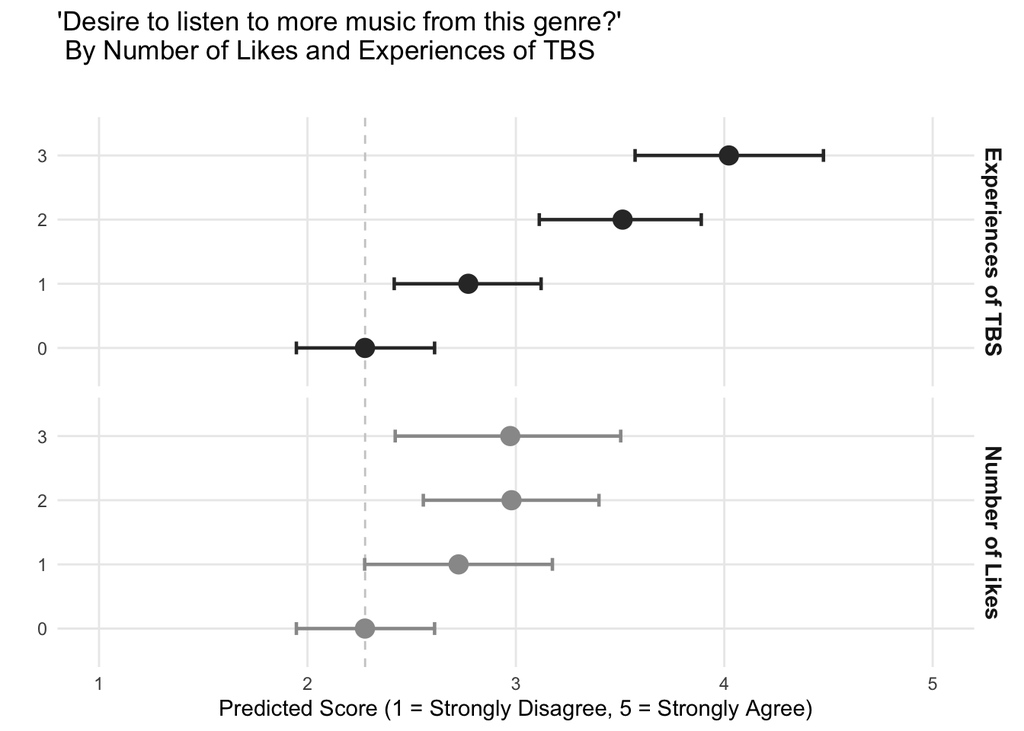

```r
# 1. TBS Enjoyment (fsat_01)
data_tbs_enjoy <- prep_plot_data(fit_sat_1_tbs, "tbs_count", "Experiences of TBS")
int_tbs_enjoy <- brms::fixef(fit_sat_1_tbs)["Intercept", "Estimate"]

plot_tbs_enjoy <- generate_custom_plot(
  plot_data = data_tbs_enjoy,
  int_est = int_tbs_enjoy,
  p_title = "'I enjoyed listening to the music?' \n By Number of Likes and Experiences of TBS",
  p_subtitle = "",
  file_name = "tbs_enjoyment_final.png"
)

# 2. TBS Intent to Listen (fsat_02)
data_tbs_intent <- prep_plot_data(fit_sat_2_tbs, "tbs_count", "Experiences of TBS")
int_tbs_intent <- brms::fixef(fit_sat_2_tbs)["Intercept", "Estimate"]

plot_tbs_intent <- generate_custom_plot(
  plot_data = data_tbs_intent,
  int_est = int_tbs_intent,
  p_title = "'Desire to listen to more music from this genre?' \n By Number of Likes and Experiences of TBS",
  p_subtitle = "",
  file_name = "tbs_intent_final.png"
)

# Display one of the plots inline for reference
plot_tbs_intent
```

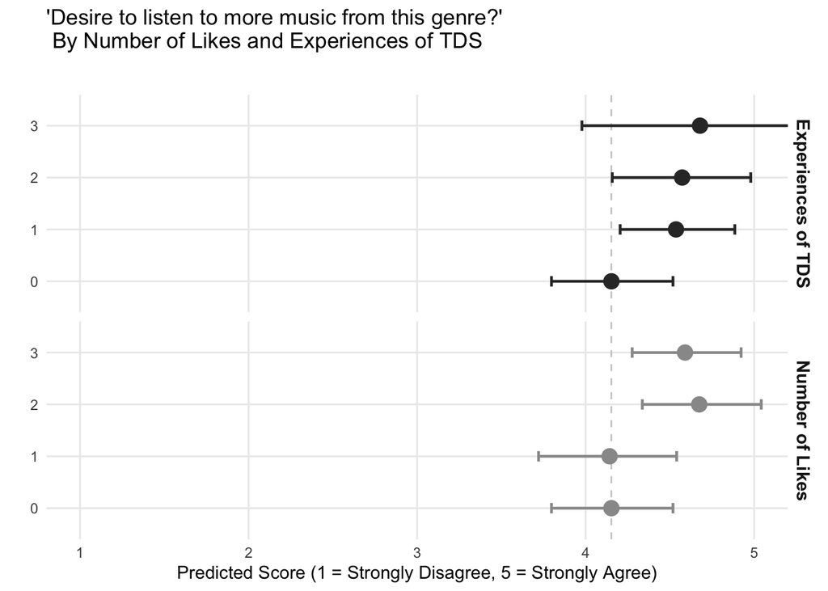

```r
# 1. TDS Enjoyment (fsat_01)
data_tds_enjoy <- prep_plot_data(fit_sat_1_tds, "tds_count", "Experiences of TDS")
int_tds_enjoy <- brms::fixef(fit_sat_1_tds)["Intercept", "Estimate"]

plot_tds_enjoy <- generate_custom_plot(
  plot_data = data_tds_enjoy,
  int_est = int_tds_enjoy,
  p_title = "'I enjoyed listening to the music?' \n By Number of Likes and Experiences of TDS",
  p_subtitle = "",
  file_name = "tds_enjoyment_final.png"
)

# 2. TDS Intent to Listen (fsat_02)
data_tds_intent <- prep_plot_data(fit_sat_2_tds, "tds_count", "Experiences of TDS")
int_tds_intent <- brms::fixef(fit_sat_2_tds)["Intercept", "Estimate"]

plot_tds_intent <- generate_custom_plot(
  plot_data = data_tds_intent,
  int_est = int_tds_intent,
  p_title = "'Desire to listen to more music from this genre?' \n By Number of Likes and Experiences of TDS",
  p_subtitle = "",
  file_name = "tds_intent_final.png"
)

# Display inline
plot_tds_intent
```